# Lesson 18 - Classes

### The following topics are discussed in this notebook:

- Classes and instances.
- Attributes and methods.
- Constructors

## Classes

A **class** is a programmer-defined data type. Python and its external packages contain many useful data types, but classes allow a programmer to create custom data types that are tailored to specific use-cases. Classes can contain functions, called **methods** as well as variables, called **attributes**. Classes are defined using the `class` keyword.

In this lesson, we will create a simple class called `circle`. Objects of this data type are intended to represent geometric circles. We will define our circle class in steps. At each step, our class will become slightly more complex.

## Circle Class: Version 1

We will start will a very basic version that contains three attributes, `r`, `x`, and `y`. The attribute `r` is intended to store the radius of the circle, while `x` and `y` store the coordinates of the circle's center point. Our class will also contain a single method, called `area`. This will return the area of the circle, rounded to two decimal places.

```python
# Version 1

class Circle:

    r = 5
    x = 0
    y = 0

    def area(self):
        pi = 3.141592653589793
        return round(pi * self.r**2, 2)
```

Notice the references to the parameter `self` in the `area` method. This will refer to the instance of `circle` from which the `area` method is called. We will say more about this in a moment.

### Creating Instances of a Class

A class is simply a template. Defining a class does not create any instances of that type. We will now create an instance of our `circle` class, storing it in a variable named `c1`.

```python
c1 = Circle()

print(type(c1))
```

```
<class '__main__.Circle'>
```

Notice that we can directly access the attributes of the class by following the class name with a period, and then the name of the attribute.

```python
print('c1 radius:', c1.r)
print('c1 center: (', c1.x, ',', c1.y, ')', sep='')
```

```
c1 radius: 5
c1 center: (0,0)
```

We can use a similar format to call a method belonging to a class instance.

```python
print('Area of c1:', c1.area())
```

```
Area of c1: 78.54
```

Notice that when we defined the `area()` method, we specified that it was to accept one parameter, named `self`. But when we called area, we apparently did not provide it with any arguments. In fact, we did. The class instance that the method is called from is always passed in as the first argument of the method. So, when we type `c1.area()`, the `circle` object `c1` is plugged in for the `self` parameter of `area`, and then when we encounter the expression `self.r` within this method, it is interpreted as `c1.r`.

Every method within a class should have a `self` parameter that appears first within the parameter list. And `self` will always refer to the class instance from which the method was called.

### Changing Attribute Values

Our circle `c1` has the default radius of `5`. We can change this by directly changing the value of `c1.r`.

```python
c1.r = 7
print('Area of c1:', c1.area())
```

```
Area of c1: 153.94
```

### Creating Multiple Instances

We can create as many instances of a class as we would like. Each such instance will be a separate object, with its own attributes and methods.

```python
c2 = Circle()
c2.r = 3

print('c1 radius:', c1.r)
print('c2 radius:', c2.r)
```

```
c1 radius: 7
c2 radius: 3
```

## Circle Class: Version 2

Notice that each of our circles starts out with a default radius of 5, and a center at (0,0). We can easily change these, but it would be helpful if we could specify the desired values when creating an instance of `circle`. We will now update our circle class to allow us to do just that.

### Constructors

A **constructor** is a method that is called when an instance of a class is created. It is intended to perform the initialization of the class object. In Python, constructors should always have the special name `__init__()`. The constructor must accept `self` as a parameter, but can also accept additional parameters to be used during initialization.

```python
class Circle:

    def __init__(self, x, y, r):
        self.x = x
        self.y = y
        self.r = r

    def area(self):
        pi = 3.141592653589793
        return pi * self.r**2
```

When a class object is created, the constructor is immediately called the object is passed to the constructor, along with any other arguments that were listed between the parentheses when the object was created. Below, we wil create a circle with a center at (5,2), and a radius of 6.

```python
c3 = Circle(5, 2, 6)

print('c3 radius:', c3.r)
print('c3 center: (', c3.x, ',', c3.y, ')', sep='')
```

```
c3 radius: 6
c3 center: (5,2)
```

This provides us with much more flexibility when creating instances of the `circle` class.

### Circle Class: Version 3

Let's complete our circle class by adding four new methods: `contains()`, `intersect()`, `copy()`, and `__str__()`.

We will discuss each of these methods in more detail after providing the definition of the class.

```python
class Circle:

    def __init__(self, x, y, r):
        self.x = x
        self.y = y
        self.r = r

    def area(self):
        pi = 3.141592653589793
        return pi * self.r**2

    def contains(self, x, y):
        # Find distance between center and new point
        dist = ( (self.x - x)**2 + (self.y - y)**2 )**0.5

        # If that distance is less than r, return True. Otherwise, return False.
        if dist < self.r:
            return True
        return False

    def intersect(self, other):
        # Find distance between two centers
        dist = ( (self.x - other.x)**2 + (self.y - other.y)**2 )**0.5

        # The circles intersect if the distance is between
        # the sum and difference of the two radii.
        if (dist >= abs(self.r - other.r)) and (dist <= self.r + other.r):
            return True
        return False

    def copy(self):
        new_circle = Circle(self.r, self.x, self.y)
        return new_circle

    def __str__(self):
        out =  f'Center: ({self.x},{self.y})\n'
        out += f'Radius: {self.r}'
        return out
```

#### The contains() Method

The `contains()` method accepts three parameters: `self`, `x`, and `y`. The parameter `self` is expected to be an instance of the `Circle` class. The parameters `x` and `y` are expected to be the coordinates of a point. This method returns `True` if the point provided lies inside the circle, and return `False` otherwise. This is accomplished by calculating the distance between the center of the circle and the new point. The point lies inside the circle if and only if that distance is less than the radius.

Notice that the `contains()` method accepts two parameters named `x` and `y`, and recall that each `circle` object has attributes named `x` and `y`. Within the method, the attributes will be stored in `self.x` and `self.y`. These will be distinct from the values of the parameters `x` and `y`. These parameter values will be created in a local scope when the method is called, and will disappear when the function finishes executing. The attributes, on the other hand, will persist as part of the object itself.

Let's now test this method.

```python
c4 = Circle(16, 20, 4)

print(c4.contains(18, 21))
print(c4.contains(19, 24))
```

```
True
False
```

#### The intersect() Method

The `intersect()` checks to see if two circles intersect. To accomplish this, the method first calculates the distance between the centers of the circles. If that distance is less than the sum of the circles' radii and greater than the absolute value of the difference between the radii, then the circles intersect.

Notice that this method is required to accept two `circle` objects as arguments. These are referred to as `self` and `other` within the function definition. The parameter `self` will, as always, reference to the `circle` instance from which the method was called. The object `other` will be provided to the method by listing it between the parentheses.

```python
c5 = Circle(x=0, y=0, r=4)
c6 = Circle(x=4, y=2, r=6)
c7 = Circle(x=5, y=4, r=1)

print('c5 and c6 intersect:', c5.intersect(c6))
print('c5 and c7 intersect:', c5.intersect(c7))
print('c6 and c7 intersect:', c6.intersect(c7))
```

```
c5 and c6 intersect: True
c5 and c7 intersect: False
c6 and c7 intersect: False
```

#### The copy() Method

As is the case with lists, when we set a variable equal to another variable containing a class instance, the new variable will refer to the currently existing instance rather than a copy of that instance. We will demonstrate this below.

```python
c8 = c7
c8.r = 3

print('c7 radius:', c7.r)
print('c8 radius:', c8.r)
```

```
c7 radius: 3
c8 radius: 3
```

```python
c9 = c8.copy()
c9.r = 9

print('c8 radius:', c8.r)
print('c9 radius:', c9.r)
```

```
c8 radius: 3
c9 radius: 9
```

#### The `__str__()` Method

Let `__init__()`, the `__str__()` method is a special method that can belong to any class, and that performs a specific function. Generally speaking, the `__str__()` method should return a string that contains some information about a particular instance of the class. This method is called whenever an instance of the class is passed to the `print()` function. In that case, the string returned by the `__str__()` method is what is actually displayed.

Notice that the `__str__()` method for the `Circle` is a string that states the center and radius of a `Circle` instance. We will now call print on a `Circle` object to confirm that this information is what is actually displayed.

```python
print(c9)
```

```
Center: (3,5)
Radius: 9
```

## Application: Sensor Network

```python
import numpy as np
import matplotlib.pyplot as plt
```

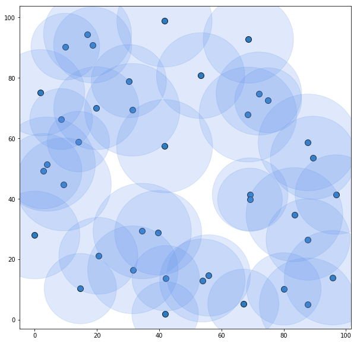

```python
np.random.seed(1)
n = 40
x_array = np.random.uniform(0, 100, n)
y_array = np.random.uniform(0, 100, n)
r_array = np.random.uniform(10, 16, n)

plt.figure(figsize=[10,10])
ax = plt.gca()
plt.scatter(x_array, y_array, edgecolor='k', s=100)
for i in range(n):
    ax.add_artist(plt.Circle((x_array[i],y_array[i]), r_array[i], color='cornflowerblue', alpha=0.2))
plt.show()
```

```python
site_list = []
for i in range(n):
    temp = Circle(x_array[i], y_array[i], r_array[i])
    site_list.append(temp)
```

```python
def count_sites(site_list, x, y):
    site_count = 0
    for i in range(len(site_list)):
        if(site_list[i].contains(x, y)):
            site_count += 1

    return site_count
```

```python
print(count_sites(site_list, 20, 82))
print(count_sites(site_list, 60, 50))
print(count_sites(site_list, 80, 90))
```

```
4
0
1
```